# Stat 420 Final Project Report

Max Piazza, David Orona, Nithya Arumugam, Abhitej Bokka

2024-12-05

# Data Analysis Project: Modeling Used Car Prices

## Introduction

In an ever-volatile market where every dollar counts, the used car market represents a critical sector of the consumer industry. With rising consumer demand and an increasing variety of vehicles entering the secondary market, understanding the factors that influence used car prices is essential. Buyers seek to make informed decisions based on value for money, while sellers aim to maximize returns by accurately pricing their vehicles. Bridging this gap requires a data-driven approach to uncover the relationships between vehicle specifications and market pricing.

This project utilizes the “Vehicle dataset” by Nehal Birla, Nishant Verma, and Nikhil Kushwaha, available on Kaggle at: https://www.kaggle.com/datasets/nehalbirla/vehicle-dataset-from-cardekho/data?select=Car+details+v3.csv.

Using statistical modeling techniques, including regression analysis, we aim to deliver a robust and interpretable model that not only predicts car prices but also highlights the most influential factors driving price variations. Our results will shed light on market dynamics, offering actionable insights for both consumers and industry professionals navigating this volatile space.

By the conclusion of this project, we aim to provide a detailed analysis that enhances understanding of the used car market, aiding stakeholders in making informed decisions in an ever-changing economic landscape.

```r
# Load and attach all needed R packages
library(tidyverse)
library(car)
library(broom)
library(MASS)
library(boot)
library(lmtest)
# Step 1: Load and Prepare Data
car_details_v3 <- read_csv("dataset/Car details v3.csv")

# Data Cleaning and Transformation
car_details_v3_clean <- car_details_v3 %>%
  rename(
    Make = name,
    Year = year,
    Price = selling_price,
    Kilometer = km_driven,
    `Fuel Type` = fuel,
    `Seller Type` = seller_type,
    Transmission = transmission,
    Mileage = mileage,
    Engine = engine,
    `Max Power` = max_power,
    Seats = seats
  ) %>%
  drop_na(Price, Kilometer, Year, `Fuel Type`, Transmission) %>%
  mutate(
    Year = as.numeric(Year),
    Transmission = as.factor(Transmission),
    `Fuel Type` = as.factor(`Fuel Type`),
    `Seller Type` = as.factor(`Seller Type`)
  )

# Check if there are any missing values in 'Price' after cleaning
sum(is.na(car_details_v3_clean$Price))  # Should return 0 if no missing values
```

```
## [1] 0
```

```r
# Ensure Price column is numeric
car_details_v3_clean$Price <- as.numeric(car_details_v3_clean$Price)

# Perform log transformation
car_details_v3_clean <- car_details_v3_clean %>%
  mutate(log_price = log(Price + 1))  # Adding 1 to avoid log(0)


# Step 2: Create Mileage and Year Bins
car_details_v3_clean <- car_details_v3_clean %>%
  mutate(
    # Simplify Mileage: Convert to numeric and bin
    Mileage_numeric = as.numeric(gsub(" kmpl| km/kg", "", Mileage)),
    Mileage_bin = cut(Mileage_numeric, breaks = c(0, 10, 15, 20, 25, Inf), labels = c("0-10", "10-15", "15-20", "20-25", "25+")),
    # Bin Year into broader categories
    Year_bin = case_when(
      Year >= 1995 & Year <= 1999 ~ "1995-1999",
      Year >= 2000 & Year <= 2004 ~ "2000-2004",
      Year >= 2005 & Year <= 2009 ~ "2005-2009",
      Year >= 2010 & Year <= 2014 ~ "2010-2014",
      Year >= 2015 & Year <= 2020 ~ "2015-2020",
      TRUE ~ "Other"
    ),
    Year_bin = factor(Year_bin, levels = c("1995-1999", "2000-2004", "2005-2009", "2010-2014", "2015-2020", "Other"))
  )

# Perform the Log Transformation of the Price column
car_details_v3_clean <- car_details_v3_clean %>%
  mutate(log_price = log(Price + 1))  # Adding 1 to avoid log(0) error

# Step 3: Exploratory Data Analysis
# Obtaining Summary statistics
summary(car_details_v3_clean)
```

```
##      Make                Year          Price            Kilometer
##  Length:8128        Min.   :1983   Min.   :   29999   Min.   :      1
##  Class :character   1st Qu.:2011   1st Qu.:  254999   1st Qu.:  35000
##  Mode  :character   Median :2015   Median :  450000   Median :  60000
##                     Mean   :2014   Mean   :  638272   Mean   :  69820
##                     3rd Qu.:2017   3rd Qu.:  675000   3rd Qu.:  98000
##                     Max.   :2020   Max.   :10000000   Max.   :2360457
##
##   Fuel Type              Seller Type      Transmission     owner
##  CNG   :  57   Dealer          :1126   Automatic:1050   Length:8128
##  Diesel:4402   Individual      :6766   Manual   :7078   Class :character
##  LPG   :  38   Trustmark Dealer: 236                    Mode  :character
##  Petrol:3631
##
##
##
##    Mileage             Engine           Max Power            torque
##  Length:8128        Length:8128        Length:8128        Length:8128
##  Class :character   Class :character   Class :character   Class :character
##  Mode  :character   Mode  :character   Mode  :character   Mode  :character
##
##
##
##
##      Seats          log_price     Mileage_numeric Mileage_bin       Year_bin
##  Min.   : 2.000   Min.   :10.31   Min.   : 0.00   0-10 :  12   1995-1999:  44
##  1st Qu.: 5.000   1st Qu.:12.45   1st Qu.:16.78   10-15:1065   2000-2004: 170
##  Median : 5.000   Median :13.02   Median :19.30   15-20:3383   2005-2009: 864
##  Mean   : 5.417   Mean   :12.97   Mean   :19.42   20-25:2701   2010-2014:2928
##  3rd Qu.: 5.000   3rd Qu.:13.42   3rd Qu.:22.32   25+  : 729   2015-2020:4117
##  Max.   :14.000   Max.   :16.12   Max.   :42.00   NA's : 238   Other    :   5
##  NA's   :221                      NA's   :221
```

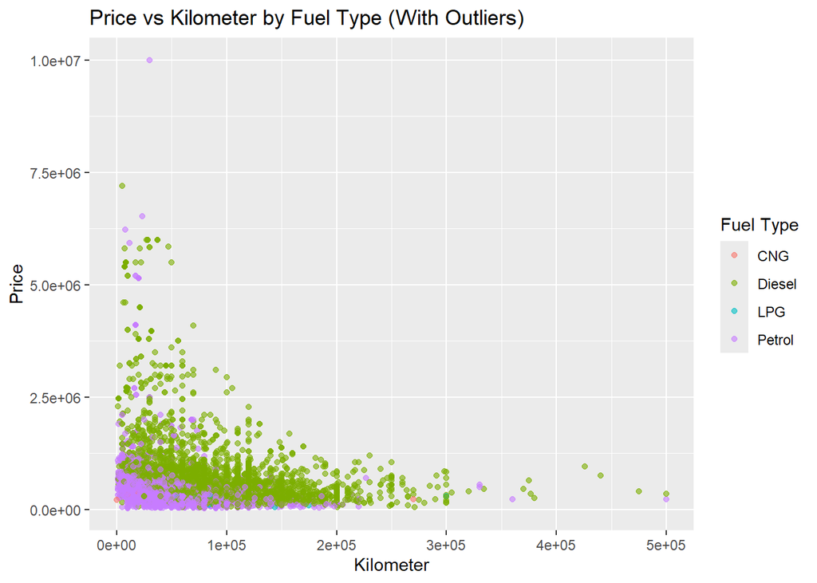

```r
# # Defining a function to remove outliers based on IQR
# remove_outliers <- function(data, column) {
#   Q1 <- quantile(data[[column]], 0.25, na.rm = TRUE)
#   Q3 <- quantile(data[[column]], 0.75, na.rm = TRUE)
#   IQR <- Q3 - Q1
#   data %>%
#     filter(data[[column]] >= (Q1 - 1.5 * IQR) & data[[column]] <= (Q3 + 1.5 * IQR))
# }
#
# # Removing outliers for plots
# car_details_no_outliers <- car_details_v3_clean %>%
#   remove_outliers("Price") %>%
#   remove_outliers("Kilometer")
#
# # Visualization: Price vs Kilometer without outliers
# ggplot(car_details_no_outliers, aes(x = Kilometer, y = Price, color = `Fuel Type`)) +
#   geom_point(alpha = 0.6) +
#   labs(title = "Price vs Kilometer by Fuel Type (No Outliers)")
#
# # Visualization: Distribution of Mileage Bins without outliers
# ggplot(car_details_no_outliers, aes(x = Mileage_bin)) +
#   geom_bar() +
#   labs(title = "Distribution of Mileage Bins (No Outliers)") +
#   theme(axis.text.x = element_text(angle = 45, hjust = 1))
#
# # Visualization: Boxplot of Price by Year Bins without outliers
# ggplot(car_details_no_outliers, aes(x = Year_bin, y = Price)) +
#   geom_boxplot() +
#   labs(title = "Price Distribution by Year Bins (No Outliers)", x = "Year Bins", y = "Price")

# Plots with outliers in data below, using ylim() and xlim() to focus on core data

# Visualization: Price vs Kilometer with Outliers
ggplot(car_details_v3_clean, aes(x = Kilometer, y = Price, color = `Fuel Type`)) +
  geom_point(alpha = 0.6) +
  labs(title = "Price vs Kilometer by Fuel Type (With Outliers)")+
       xlim(0,500000)
```

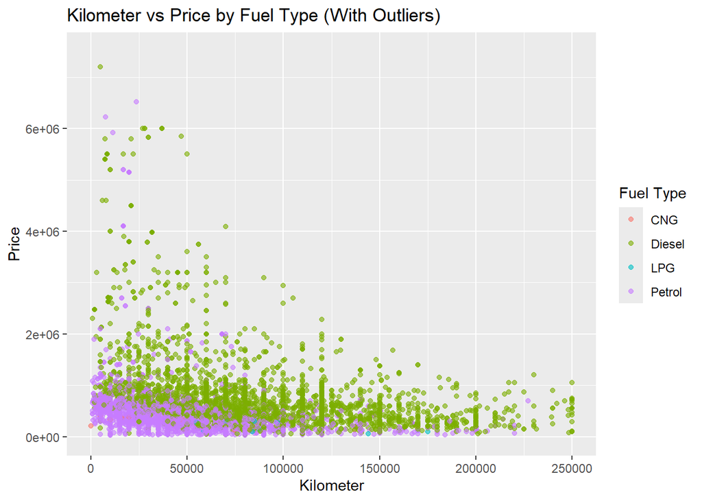

```r
# Visualization: Kilometer vs Price with Outliers (Axes limited)
ggplot(car_details_v3_clean, aes(x = Kilometer, y = Price, color = `Fuel Type`)) +
  geom_point(alpha = 0.6) +
  labs(title = "Kilometer vs Price by Fuel Type (With Outliers)") +
  xlim(0, 250000) +          # Limit x-axis to 250,000
  ylim(0, 7.5e+06)           # Limit y-axis to 7.5 million
```

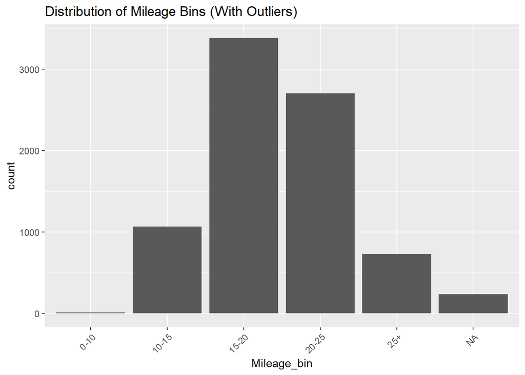

```r
# Visualization: Distribution of Mileage Bins with Outliers
ggplot(car_details_v3_clean, aes(x = Mileage_bin)) +
  geom_bar() +
  labs(title = "Distribution of Mileage Bins (With Outliers)") +
  theme(axis.text.x = element_text(angle = 45, hjust = 1))
```

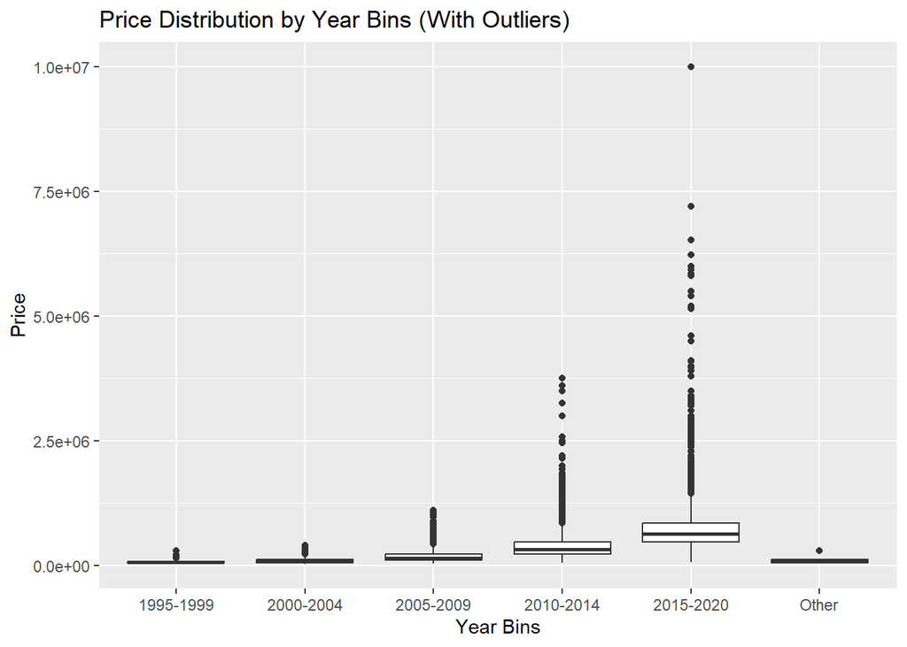

```r
# Visualization: Boxplot of Price by Year Bins with Outliers
ggplot(car_details_v3_clean, aes(x = Year_bin, y = Price)) +
  geom_boxplot() +
  labs(title = "Price Distribution by Year Bins (With Outliers)", x = "Year Bins", y = "Price")
```

```r
# Step 4: Develop and Refine Model
# Our Initial model
model_initial <- lm(Price ~ Kilometer + `Fuel Type` + Transmission + Mileage_bin + Seats + Year_bin, data = car_details_v3_clean)

# Checking for multicollinearity using VIF
vif_initial <- vif(model_initial)
print(vif_initial)
```

```
##                  GVIF Df GVIF^(1/(2*Df))
## Kilometer    1.382108  1        1.175631
## `Fuel Type`  1.424898  3        1.060793
## Transmission 1.241282  1        1.114128
## Mileage_bin  2.109384  4        1.097790
## Seats        1.735053  1        1.317214
## Year_bin     1.606900  5        1.048574
```

```r
# Refining model using stepwise selection
model_refined <- step(model_initial, direction = "both")
```

```
## Start:  AIC=209464.8
## Price ~ Kilometer + `Fuel Type` + Transmission + Mileage_bin +
##     Seats + Year_bin
##
##                Df  Sum of Sq        RSS    AIC
## <none>                       2.6609e+15 209465
## - Seats         1 9.4776e+12 2.6704e+15 209491
## - Kilometer     1 4.0611e+13 2.7015e+15 209582
## - Mileage_bin   4 1.4041e+14 2.8013e+15 209863
## - Year_bin      5 2.7355e+14 2.9344e+15 210227
## - `Fuel Type`   3 3.2379e+14 2.9847e+15 210365
## - Transmission  1 9.5156e+14 3.6124e+15 211875
```

```r
summary(model_refined)
```

```
##
## Call:
## lm(formula = Price ~ Kilometer + `Fuel Type` + Transmission +
##     Mileage_bin + Seats + Year_bin, data = car_details_v3_clean)
##
## Residuals:
##      Min       1Q   Median       3Q      Max
## -1884051  -188915   -14144   152867  8559815
##
## Coefficients:
##                      Estimate Std. Error t value Pr(>|t|)
## (Intercept)         2.686e+06  2.144e+05  12.528  < 2e-16 ***
## Kilometer          -1.484e+00  1.354e-01 -10.962  < 2e-16 ***
## `Fuel Type`Diesel   2.948e+05  8.094e+04   3.643 0.000271 ***
## `Fuel Type`LPG     -2.236e+04  1.271e+05  -0.176 0.860353
## `Fuel Type`Petrol  -1.861e+05  8.150e+04  -2.284 0.022423 *
## TransmissionManual -1.146e+06  2.160e+04 -53.064  < 2e-16 ***
## Mileage_bin10-15   -9.923e+05  1.698e+05  -5.844 5.29e-09 ***
## Mileage_bin15-20   -1.021e+06  1.690e+05  -6.041 1.60e-09 ***
## Mileage_bin20-25   -1.291e+06  1.694e+05  -7.620 2.83e-14 ***
## Mileage_bin25+     -1.423e+06  1.710e+05  -8.322  < 2e-16 ***
## Seats              -4.761e+04  8.991e+03  -5.296 1.22e-07 ***
## Year_bin2000-2004   1.782e+04  1.109e+05   0.161 0.872305
## Year_bin2005-2009   2.553e+04  1.007e+05   0.254 0.799856
## Year_bin2010-2014   2.045e+05  9.966e+04   2.052 0.040179 *
## Year_bin2015-2020   5.982e+05  9.998e+04   5.983 2.29e-09 ***
## Year_binOther      -1.829e+05  4.228e+05  -0.433 0.665227
## ---
## Signif. codes:  0 '***' 0.001 '**' 0.01 '*' 0.05 '.' 0.1 ' ' 1
##
## Residual standard error: 581300 on 7874 degrees of freedom
##   (238 observations deleted due to missingness)
## Multiple R-squared:  0.4903, Adjusted R-squared:  0.4893
## F-statistic: 504.9 on 15 and 7874 DF,  p-value: < 2.2e-16
```

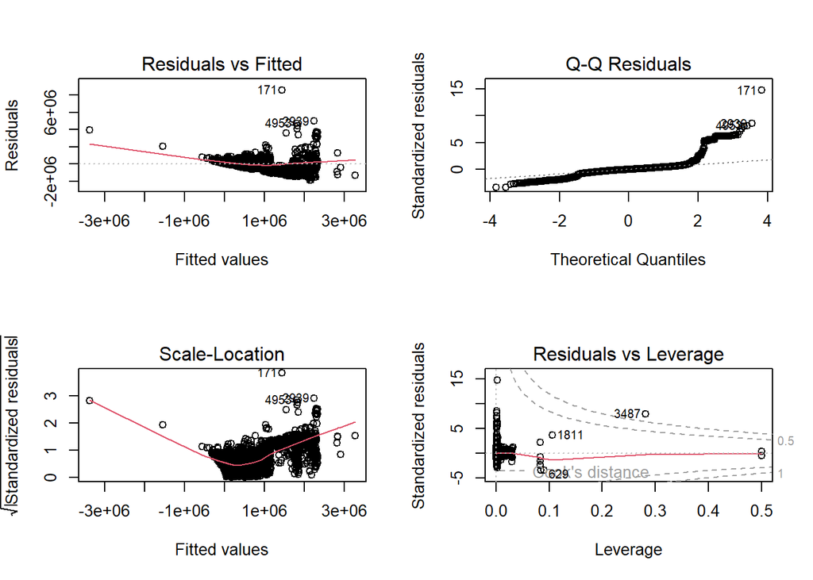

```r
# Extract the data used in the refined model into a data frame for analysis
model_data <- model.frame(model_refined)

# Step 5: Residual Diagnostics
# Diagnostic Plots
par(mfrow = c(2, 2))
plot(model_refined)
```

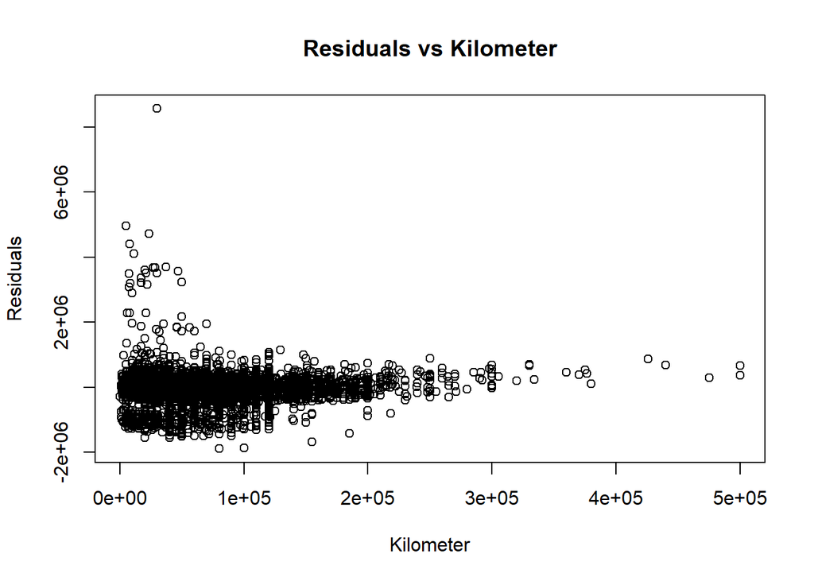

```r
par(mfrow = c(1, 1))

# Scatter plot of residuals vs Kilometer
plot(model_data$Kilometer, residuals(model_refined),
     xlab = "Kilometer", ylab = "Residuals",
     main = "Residuals vs Kilometer",
     xlim = c(0, 500000)  # Limit the x-axis to a maximum of 500,000 for better visualization
     )
```

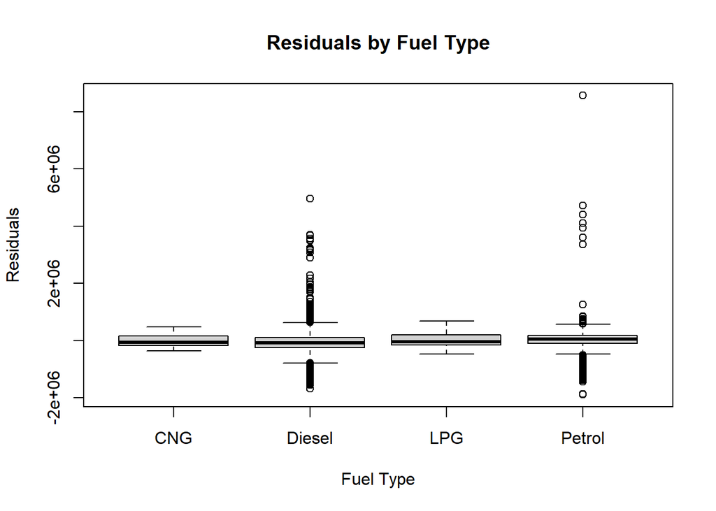

```r
# Boxplot of residuals by Fuel Type
boxplot(residuals(model_refined) ~ model_data$`Fuel Type`,
        xlab = "Fuel Type", ylab = "Residuals",
        main = "Residuals by Fuel Type")
```

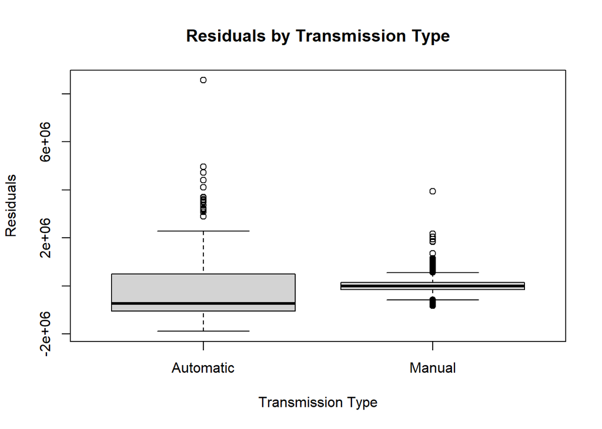

```r
# Boxplot of residuals by transmission
boxplot(residuals(model_refined) ~ model_data$Transmission,
        xlab = "Transmission Type", ylab = "Residuals",
        main = "Residuals by Transmission Type")
```

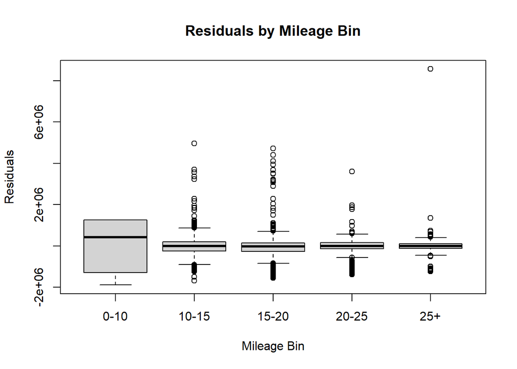

```r
# Boxplot of residuals by mileage category
boxplot(residuals(model_refined) ~ model_data$Mileage_bin,
        xlab = "Mileage Bin", ylab = "Residuals",
        main = "Residuals by Mileage Bin")
```

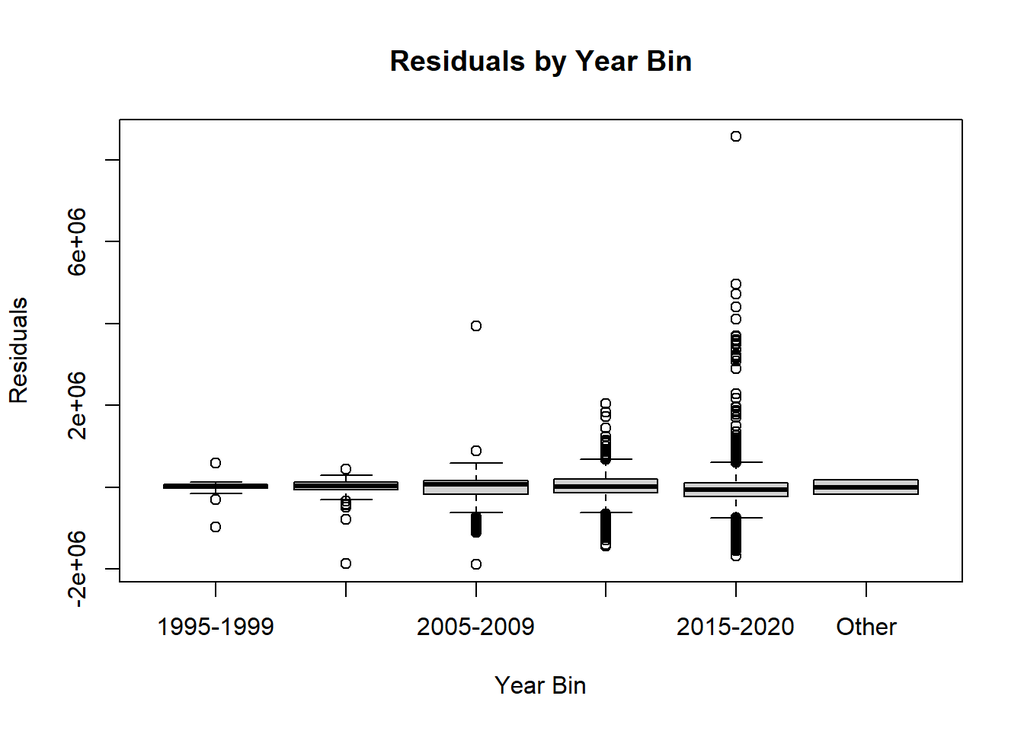

```r
# Boxplot of residuals grouped by Year Bin
boxplot(residuals(model_refined) ~ model_data$Year_bin,
        xlab = "Year Bin", ylab = "Residuals",
        main = "Residuals by Year Bin")
```

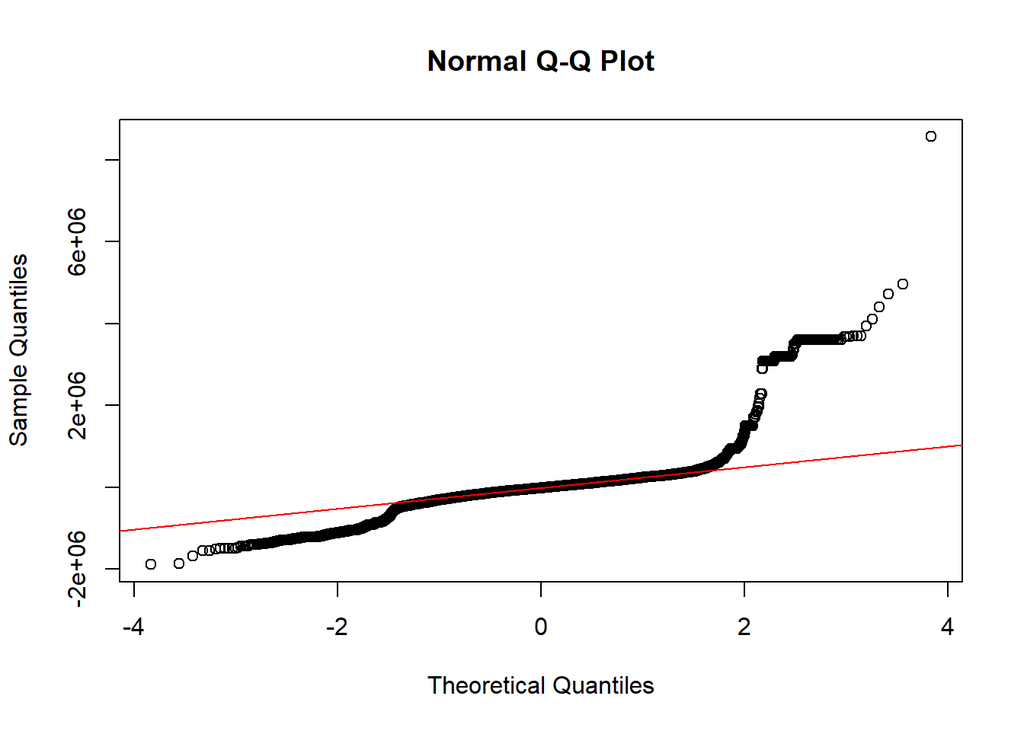

```r
# Testing for normality of residuals using Q-Q plot
qqnorm(residuals(model_refined))
qqline(residuals(model_refined), col = "red")
```

```r
# Testing for homoscedasticity using Breusch-Pagan test
bp_test <- bptest(model_refined)
print(bp_test)
```

```
##
##  studentized Breusch-Pagan test
##
## data:  model_refined
## BP = 1492.5, df = 15, p-value < 2.2e-16
```

```r
# Step 6: Model Validation
# Spliting data into training and testing sets
set.seed(123)
train_indices <- sample(1:nrow(car_details_v3_clean), size = 0.7 * nrow(car_details_v3_clean))
train_data <- car_details_v3_clean[train_indices, ]
test_data <- car_details_v3_clean[-train_indices, ]

# Training model
model_train <- lm(Price ~ Kilometer + `Fuel Type` + Transmission + Mileage_bin + Seats + Year_bin, data = train_data)

# Working with predictions
predictions <- predict(model_train, newdata = test_data)
actuals <- test_data$Price

# Calculating RMSE and R-squared
rmse <- sqrt(mean((predictions - actuals)^2))
r_squared <- 1 - (sum((predictions - actuals)^2) / sum((actuals - mean(actuals))^2))

cat("RMSE:", rmse, "\nR-squared:", r_squared, "\n")
```

```
## RMSE: NA
## R-squared: NA
```

```r
# Step 7: Confidence Intervals and ANOVA
# Confidence intervals for coefficients
conf_intervals <- confint(model_refined)
print(conf_intervals)
```

```
##                            2.5 %        97.5 %
## (Intercept)         2.266076e+06  3.106802e+06
## Kilometer          -1.749787e+00 -1.218928e+00
## `Fuel Type`Diesel   1.361800e+05  4.535109e+05
## `Fuel Type`LPG     -2.715388e+05  2.268124e+05
## `Fuel Type`Petrol  -3.458765e+05 -2.634977e+04
## TransmissionManual -1.188428e+06 -1.103752e+06
## Mileage_bin10-15   -1.325194e+06 -6.595054e+05
## Mileage_bin15-20   -1.352560e+06 -6.898228e+05
## Mileage_bin20-25   -1.623369e+06 -9.590421e+05
## Mileage_bin25+     -1.758587e+06 -1.088052e+06
## Seats              -6.523605e+04 -2.998846e+04
## Year_bin2000-2004  -1.995119e+05  2.351533e+05
## Year_bin2005-2009  -1.718895e+05  2.229595e+05
## Year_bin2010-2014   9.166612e+03  3.998715e+05
## Year_bin2015-2020   4.021783e+05  7.941385e+05
## Year_binOther      -1.011674e+06  6.457922e+05
```

```r
# Obtaining ANOVA for variable significance
anova_results <- anova(model_refined)
print(anova_results)
```

```
## Analysis of Variance Table
##
## Response: Price
##                Df     Sum Sq    Mean Sq   F value Pr(>F)
## Kilometer       1 2.5897e+14 2.5897e+14  766.3416 <2e-16 ***
## `Fuel Type`     3 3.9450e+14 1.3150e+14  389.1336 <2e-16 ***
## Transmission    1 1.5700e+15 1.5700e+15 4645.9352 <2e-16 ***
## Mileage_bin     4 6.1668e+13 1.5417e+13   45.6217 <2e-16 ***
## Seats           1 5.7231e+11 5.7231e+11    1.6936 0.1932
## Year_bin        5 2.7355e+14 5.4710e+13  161.8963 <2e-16 ***
## Residuals    7874 2.6609e+15 3.3793e+11
## ---
## Signif. codes:  0 '***' 0.001 '**' 0.01 '*' 0.05 '.' 0.1 ' ' 1
```

```r
# Step 8: Final Model Interpretation
cat("Final Model Summary:\n")
```

```
## Final Model Summary:
```

```r
summary(model_refined)
```

```
##
## Call:
## lm(formula = Price ~ Kilometer + `Fuel Type` + Transmission +
##     Mileage_bin + Seats + Year_bin, data = car_details_v3_clean)
##
## Residuals:
##      Min       1Q   Median       3Q      Max
## -1884051  -188915   -14144   152867  8559815
##
## Coefficients:
##                      Estimate Std. Error t value Pr(>|t|)
## (Intercept)         2.686e+06  2.144e+05  12.528  < 2e-16 ***
## Kilometer          -1.484e+00  1.354e-01 -10.962  < 2e-16 ***
## `Fuel Type`Diesel   2.948e+05  8.094e+04   3.643 0.000271 ***
## `Fuel Type`LPG     -2.236e+04  1.271e+05  -0.176 0.860353
## `Fuel Type`Petrol  -1.861e+05  8.150e+04  -2.284 0.022423 *
## TransmissionManual -1.146e+06  2.160e+04 -53.064  < 2e-16 ***
## Mileage_bin10-15   -9.923e+05  1.698e+05  -5.844 5.29e-09 ***
## Mileage_bin15-20   -1.021e+06  1.690e+05  -6.041 1.60e-09 ***
## Mileage_bin20-25   -1.291e+06  1.694e+05  -7.620 2.83e-14 ***
## Mileage_bin25+     -1.423e+06  1.710e+05  -8.322  < 2e-16 ***
## Seats              -4.761e+04  8.991e+03  -5.296 1.22e-07 ***
## Year_bin2000-2004   1.782e+04  1.109e+05   0.161 0.872305
## Year_bin2005-2009   2.553e+04  1.007e+05   0.254 0.799856
## Year_bin2010-2014   2.045e+05  9.966e+04   2.052 0.040179 *
## Year_bin2015-2020   5.982e+05  9.998e+04   5.983 2.29e-09 ***
## Year_binOther      -1.829e+05  4.228e+05  -0.433 0.665227
## ---
## Signif. codes:  0 '***' 0.001 '**' 0.01 '*' 0.05 '.' 0.1 ' ' 1
##
## Residual standard error: 581300 on 7874 degrees of freedom
##   (238 observations deleted due to missingness)
## Multiple R-squared:  0.4903, Adjusted R-squared:  0.4893
## F-statistic: 504.9 on 15 and 7874 DF,  p-value: < 2.2e-16
```

```r
# Step 9: Finding Alternate Models and Performing Diagnostic Checking

# Log Transformation of Response Model
transformed_model <- lm(log_price ~ Kilometer + Year_bin + `Fuel Type` + Transmission + Seats, data = car_details_v3_clean)
summary(transformed_model)
```

```
##
## Call:
## lm(formula = log_price ~ Kilometer + Year_bin + `Fuel Type` +
##     Transmission + Seats, data = car_details_v3_clean)
##
## Residuals:
##     Min      1Q  Median      3Q     Max
## -1.7357 -0.3107  0.0084  0.2933  3.7167
##
## Coefficients:
##                      Estimate Std. Error t value Pr(>|t|)
## (Intercept)         1.140e+01  1.067e-01 106.841   <2e-16 ***
## Kilometer          -9.872e-07  1.084e-07  -9.104   <2e-16 ***
## Year_bin2000-2004   2.261e-01  8.910e-02   2.538   0.0112 *
## Year_bin2005-2009   7.252e-01  8.092e-02   8.963   <2e-16 ***
## Year_bin2010-2014   1.300e+00  7.981e-02  16.283   <2e-16 ***
## Year_bin2015-2020   1.911e+00  7.981e-02  23.944   <2e-16 ***
## Year_binOther      -9.208e-02  3.398e-01  -0.271   0.7864
## `Fuel Type`Diesel   5.567e-01  6.478e-02   8.594   <2e-16 ***
## `Fuel Type`LPG      5.036e-02  1.020e-01   0.494   0.6214
## `Fuel Type`Petrol   9.470e-02  6.478e-02   1.462   0.1438
## TransmissionManual -9.628e-01  1.613e-02 -59.680   <2e-16 ***
## Seats               1.147e-01  5.942e-03  19.295   <2e-16 ***
## ---
## Signif. codes:  0 '***' 0.001 '**' 0.01 '*' 0.05 '.' 0.1 ' ' 1
##
## Residual standard error: 0.4673 on 7895 degrees of freedom
##   (221 observations deleted due to missingness)
## Multiple R-squared:  0.6818, Adjusted R-squared:  0.6813
## F-statistic:  1538 on 11 and 7895 DF,  p-value: < 2.2e-16
```

```r
# BP Test for Log-Transformed Model
bptest(transformed_model)
```

```
##
##  studentized Breusch-Pagan test
##
## data:  transformed_model
## BP = 1357.3, df = 11, p-value < 2.2e-16
```

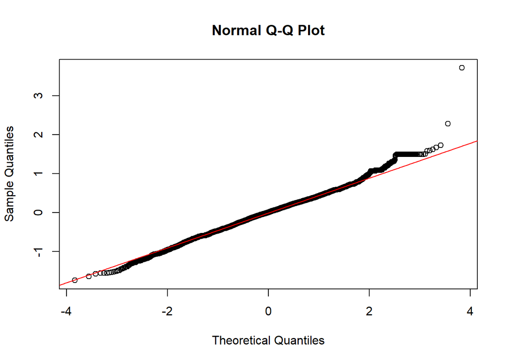

```r
# QQ Plot for Log-Transformed Model
qqnorm(residuals(transformed_model))
qqline(residuals(transformed_model), col = "red")
```

## Methods

## Results

## Discussion

## Appendix